# exp2_IntOccDiff

William Sheppard

29/05/2020

# This script investigates the effect of removing participants with no interocular difference or large interocular difference on CKAT measures

data: data frame dv: (numeric) the dependent (or outcome) variable name. wid: variable name specifying the case/sample identifier. within: within-subjects factor or grouping variable

# Aiming

One-way repeated measures anova dv = MT wid = P_ID_ within = visual condition

## All data

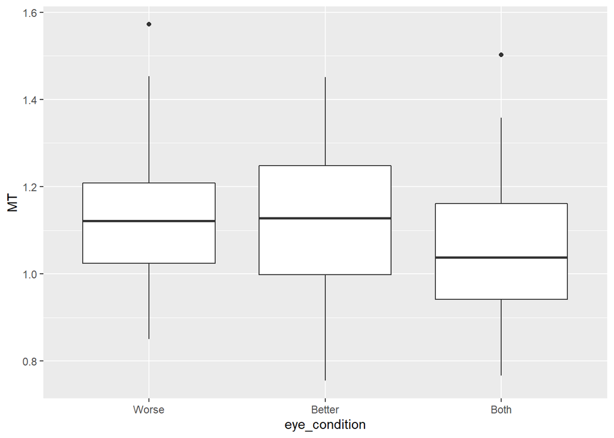

```
## ANOVA Table (type III tests)
##
##          Effect DFn DFd     F       p p<.05   pes
## 1 eye_condition   2 142 12.61 9.1e-06     * 0.151
```

```
## # A tibble: 3 x 10
##   .y.   group1 group2    n1    n2 statistic    df        p    p.adj p.adj.signif
## * <chr> <chr>  <chr>  <int> <int>     <dbl> <dbl>    <dbl>    <dbl> <chr>
## 1 MT    Worse  Better    72    72     0.705    71  4.83e-1  4.83e-1 ns
## 2 MT    Worse  Both      72    72     4.73     71  1.11e-5  3.33e-5 ****
## 3 MT    Better Both      72    72     3.89     71  2.27e-4  4.54e-4 ***
```

```
## # A tibble: 3 x 7
##   .y.   group1 group2 effsize    n1    n2 magnitude
## * <chr> <chr>  <chr>    <dbl> <int> <int> <ord>
## 1 MT    Worse  Better  0.0831    72    72 negligible
## 2 MT    Worse  Both    0.557     72    72 moderate
## 3 MT    Better Both    0.458     72    72 small
```

## Aiming - Interoccular difference == 0.0 logMAR removed

results are almost exactly the same as including all data! Effect sizes are slightly smaller after excluding data.

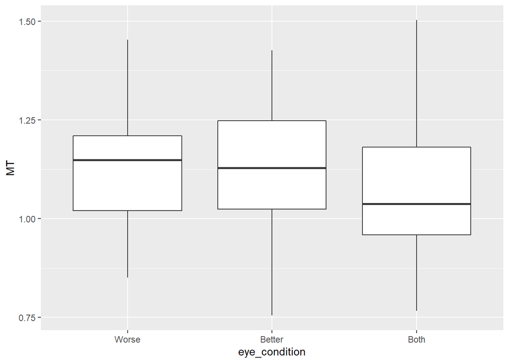

```
## ANOVA Table (type III tests)
##
##          Effect DFn DFd     F        p p<.05   pes
## 1 eye_condition   2 112 8.569 0.000344     * 0.133
```

```
## # A tibble: 3 x 10
##   .y.   group1 group2    n1    n2 statistic    df       p p.adj p.adj.signif
## * <chr> <chr>  <chr>  <int> <int>     <dbl> <dbl>   <dbl> <dbl> <chr>
## 1 MT    Worse  Better    57    57     0.439    56 0.663   0.663 ns
## 2 MT    Worse  Both      57    57     3.79     56 0.00037 0.001 **
## 3 MT    Better Both      57    57     3.33     56 0.002   0.003 **
```

```
## # A tibble: 3 x 7
##   .y.   group1 group2 effsize    n1    n2 magnitude
## * <chr> <chr>  <chr>    <dbl> <int> <int> <ord>
## 1 MT    Worse  Better  0.0581    57    57 negligible
## 2 MT    Worse  Both    0.502     57    57 moderate
## 3 MT    Better Both    0.441     57    57 small
```

## Aiming - Interoccular difference > 0.2 logMAR removed

```
## # A tibble: 3 x 5
##   eye_condition variable     n  mean    sd
##   <fct>         <chr>    <dbl> <dbl> <dbl>
## 1 Worse         MT          61  1.13 0.146
## 2 Better        MT          61  1.12 0.166
## 3 Both          MT          61  1.05 0.139
```

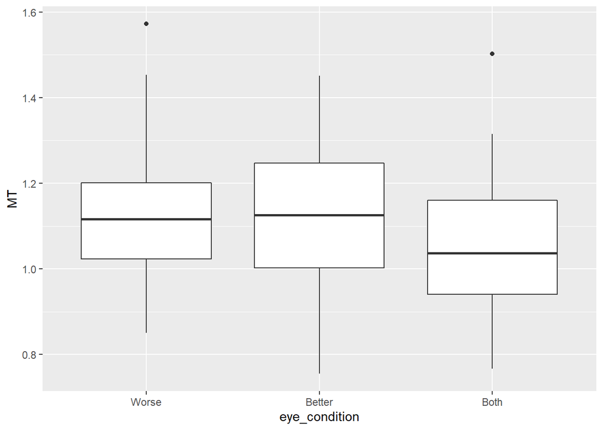

```
## ANOVA Table (type III tests)
##
##          Effect DFn DFd      F        p p<.05   pes
## 1 eye_condition   2 120 11.771 2.15e-05     * 0.164
```

```
## # A tibble: 3 x 10
##   .y.   group1 group2    n1    n2 statistic    df        p    p.adj p.adj.signif
## * <chr> <chr>  <chr>  <int> <int>     <dbl> <dbl>    <dbl>    <dbl> <chr>
## 1 MT    Worse  Better    61    61     0.733    60  4.66e-1  4.66e-1 ns
## 2 MT    Worse  Both      61    61     4.59     60  2.35e-5  7.05e-5 ****
## 3 MT    Better Both      61    61     3.74     60  4.18e-4  8.36e-4 ***
```

```
## # A tibble: 3 x 7
##   .y.   group1 group2 effsize    n1    n2 magnitude
## * <chr> <chr>  <chr>    <dbl> <int> <int> <ord>
## 1 MT    Worse  Better  0.0938    61    61 negligible
## 2 MT    Worse  Both    0.587     61    61 moderate
## 3 MT    Better Both    0.478     61    61 small
```

## Aiming - Interoccular difference < 0.2 logMAR removed

No significant main effect of vision. Sample size is now much smaller - may exlain the lack of effect (N = 11)

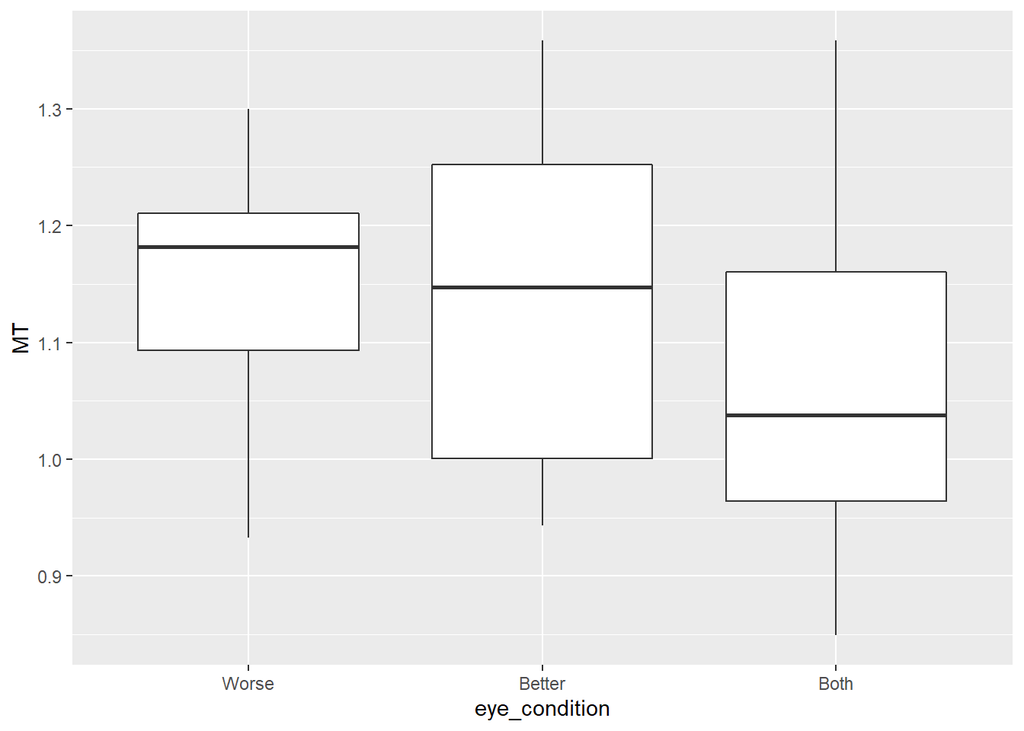

```
## ANOVA Table (type III tests)
##
##          Effect DFn DFd     F     p p<.05   pes
## 1 eye_condition   2  20 1.165 0.332       0.104
```

# Steering

## Two-way repeated measures anova

dv = pPA wid = P_ID_ within = visual condition, shape

It appears that steering dat ais non-normally distributed for some conditions shape A - Worse and Better, shape B - Worse All same results, i got different values for cohens d: better vs both = 0.28 worse vs both = 0.33

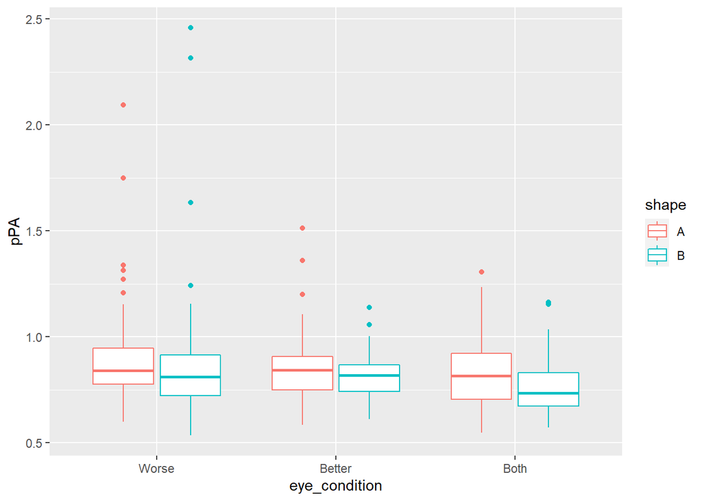

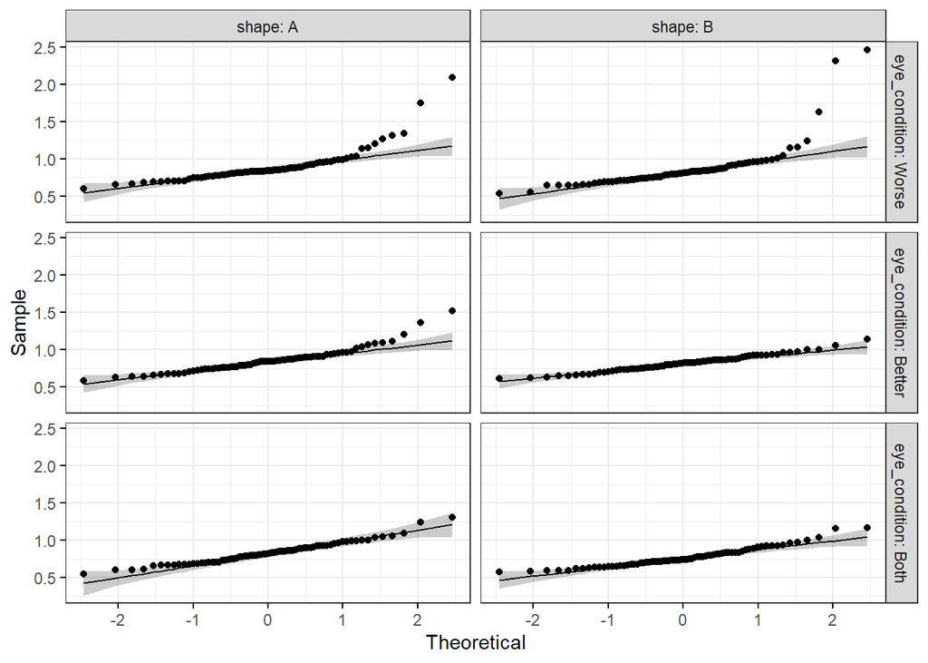

```
## ANOVA Table (type III tests)
##
##                Effect  DFn   DFd     F     p p<.05   pes
## 1       eye_condition 1.38 97.77 8.939 0.001     * 0.112
## 2               shape 1.00 71.00 8.160 0.006     * 0.103
## 3 eye_condition:shape 1.25 89.03 0.543 0.502       0.008
```

```
## # A tibble: 3 x 10
##   .y.   group1 group2    n1    n2 statistic    df        p   p.adj p.adj.signif
## * <chr> <chr>  <chr>  <int> <int>     <dbl> <dbl>    <dbl>   <dbl> <chr>
## 1 pPA   Worse  Better   144   144      2.31   143 0.022    0.022   *
## 2 pPA   Worse  Both     144   144      3.93   143 0.000130 0.00039 ***
## 3 pPA   Better Both     144   144      3.30   143 0.001    0.002   **
```

```
## # A tibble: 3 x 7
##   .y.   group1 group2 effsize    n1    n2 magnitude
## * <chr> <chr>  <chr>    <dbl> <int> <int> <ord>
## 1 pPA   Worse  Better   0.192   144   144 negligible
## 2 pPA   Worse  Both     0.328   144   144 small
## 3 pPA   Better Both     0.275   144   144 small
```

## Steering - Interoccular difference == 0.0 logMAR removed

It appears that steering dat ais non-normally distributed for some conditions shape A - Worse and Better, shape B - Worse compared to all data, effect size of better v both has increased from 0.28 to 0.34

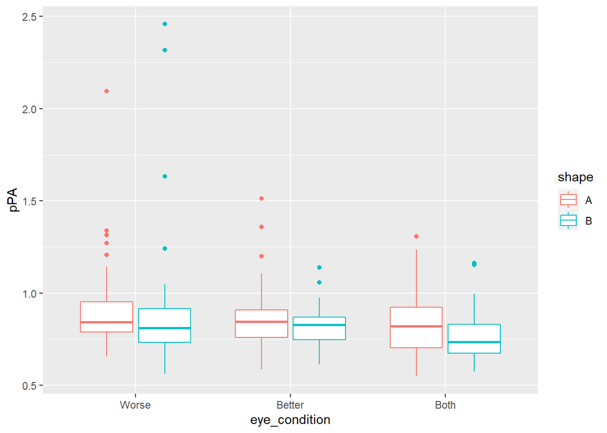

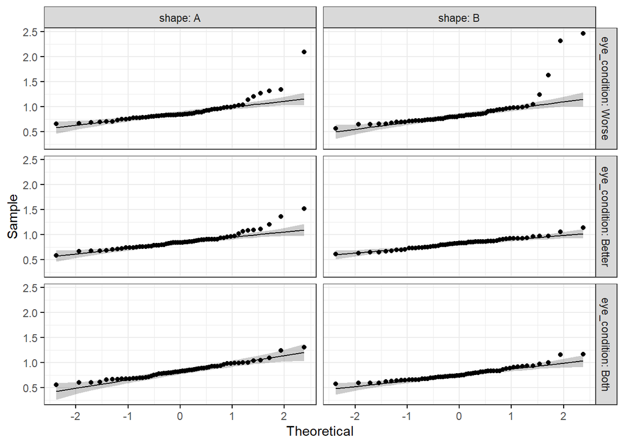

```
## ANOVA Table (type III tests)
##
##                Effect  DFn   DFd     F     p p<.05   pes
## 1       eye_condition 1.36 75.89 7.264 0.004     * 0.115
## 2               shape 1.00 56.00 5.223 0.026     * 0.085
## 3 eye_condition:shape 1.24 69.63 0.664 0.449       0.012
```

```
## # A tibble: 3 x 10
##   .y.   group1 group2    n1    n2 statistic    df        p p.adj p.adj.signif
## * <chr> <chr>  <chr>  <int> <int>     <dbl> <dbl>    <dbl> <dbl> <chr>
## 1 pPA   Worse  Better   114   114      1.81   113 0.073    0.073 ns
## 2 pPA   Worse  Both     114   114      3.55   113 0.000571 0.001 **
## 3 pPA   Better Both     114   114      3.62   113 0.000441 0.001 **
```

```
## # A tibble: 3 x 7
##   .y.   group1 group2 effsize    n1    n2 magnitude
## * <chr> <chr>  <chr>    <dbl> <int> <int> <ord>
## 1 pPA   Worse  Better   0.170   114   114 negligible
## 2 pPA   Worse  Both     0.332   114   114 small
## 3 pPA   Better Both     0.339   114   114 small
```

## Steering - Interoccular difference > 0.2 logMAR removed

```
## # A tibble: 6 x 6
##   shape eye_condition variable     n  mean    sd
##   <chr> <fct>         <chr>    <dbl> <dbl> <dbl>
## 1 A     Worse         pPA         61 0.889 0.233
## 2 A     Better        pPA         61 0.851 0.163
## 3 A     Both          pPA         61 0.829 0.149
## 4 B     Worse         pPA         61 0.871 0.324
## 5 B     Better        pPA         61 0.813 0.109
## 6 B     Both          pPA         61 0.765 0.133
```

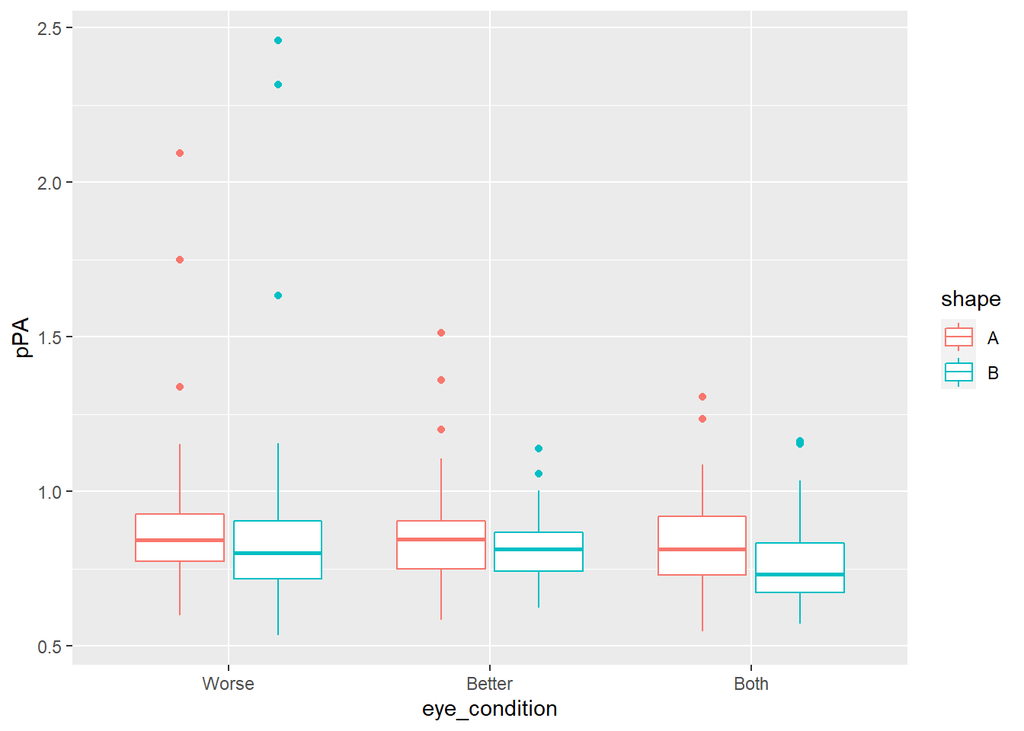

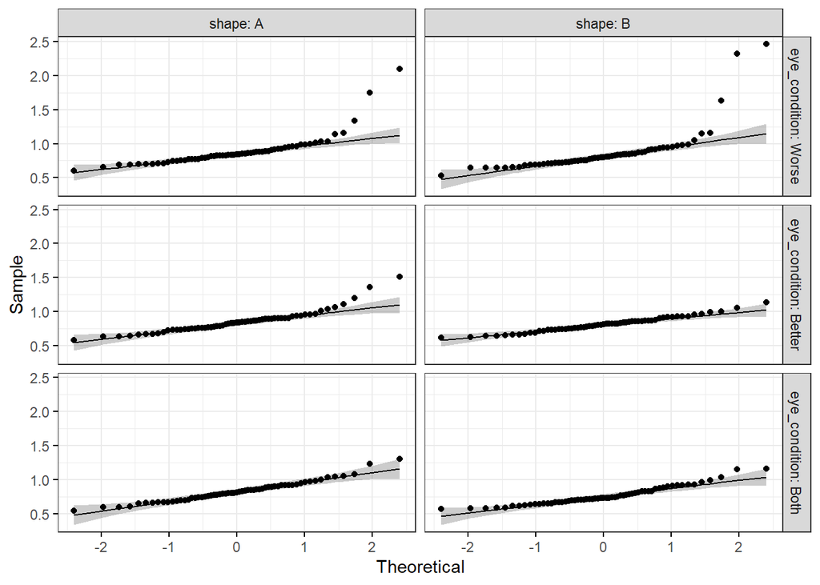

```
## ANOVA Table (type III tests)
##
##                Effect  DFn   DFd     F     p p<.05   pes
## 1       eye_condition 1.34 80.51 6.750 0.006     * 0.101
## 2               shape 1.00 60.00 5.721 0.020     * 0.087
## 3 eye_condition:shape 1.22 73.18 0.647 0.453       0.011
```

```
## # A tibble: 3 x 10
##   .y.   group1 group2    n1    n2 statistic    df     p p.adj p.adj.signif
## * <chr> <chr>  <chr>  <int> <int>     <dbl> <dbl> <dbl> <dbl> <chr>
## 1 pPA   Worse  Better   122   122      1.85   121 0.066 0.066 ns
## 2 pPA   Worse  Both     122   122      3.35   121 0.001 0.003 **
## 3 pPA   Better Both     122   122      3.16   121 0.002 0.004 **
```

```
## # A tibble: 3 x 7
##   .y.   group1 group2 effsize    n1    n2 magnitude
## * <chr> <chr>  <chr>    <dbl> <int> <int> <ord>
## 1 pPA   Worse  Better   0.168   122   122 negligible
## 2 pPA   Worse  Both     0.304   122   122 small
## 3 pPA   Better Both     0.286   122   122 small
```

## Steering - Interoccular difference < 0.2 logMAR removed

No main effect of vision

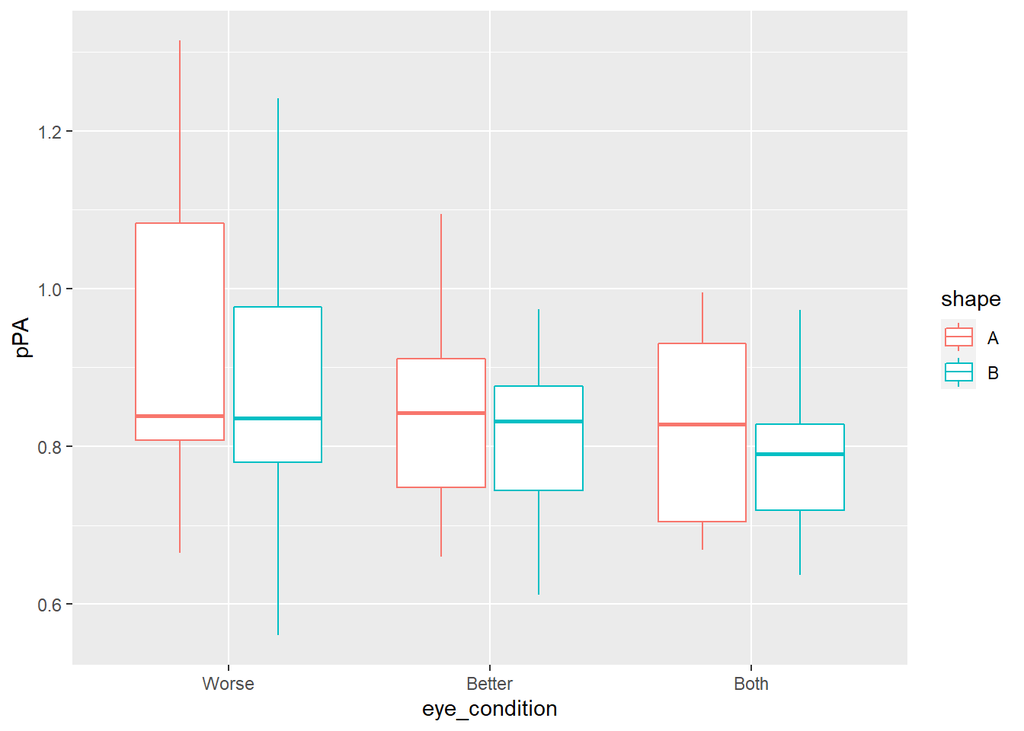

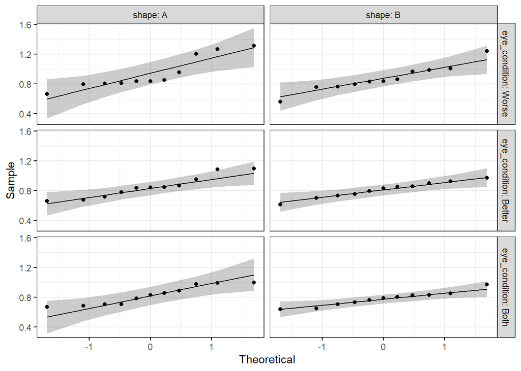

```
## ANOVA Table (type III tests)
##
##                Effect DFn DFd     F     p p<.05   pes
## 1       eye_condition   2  20 2.323 0.124       0.189
## 2               shape   1  10 4.538 0.059       0.312
## 3 eye_condition:shape   2  20 0.265 0.770       0.026
```

# Tracking

## Three-way repeated measures anova

dv = RMSE wid = P_ID_ within = visual condition, speed, guide

Some conditions are not normally distributed, see qq plot for details

No main effect of eye condition. Main effect of guide and speed, and a sig. guide*speed interaction. Not interested in this effect in this paper, therefore, I am not probing this any further.

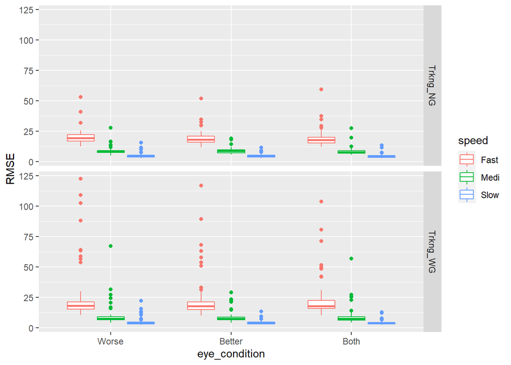

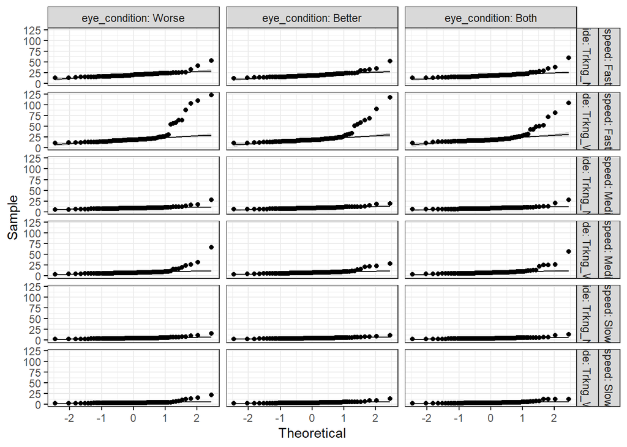

```
## ANOVA Table (type III tests)
##
##                      Effect  DFn    DFd       F        p p<.05   pes
## 1             eye_condition 1.65 115.68   1.436 2.42e-01       0.020
## 2                     speed 1.04  72.59 235.212 7.18e-25     * 0.771
## 3                     guide 1.00  70.00   5.291 2.40e-02     * 0.070
## 4       eye_condition:speed 1.65 115.58   0.995 3.60e-01       0.014
## 5       eye_condition:guide 1.43 100.25   0.671 4.66e-01       0.009
## 6               speed:guide 1.07  74.65  10.100 2.00e-03     * 0.126
## 7 eye_condition:speed:guide 1.71 119.42   0.518 5.68e-01       0.007
```

## Tracking - Interoccular difference == 0.0 logMAR removed

Some conditions are not normally distributed, see qq plot for details

No main effect of eye condition. Main effect of guide and speed, and a sig. guide*speed interaction. Not interested in this effect in this paper, therefore, I am not probing this any further.

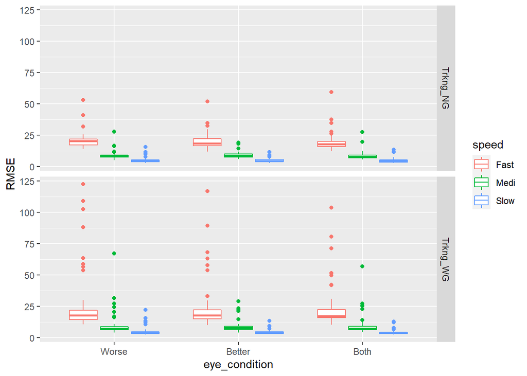

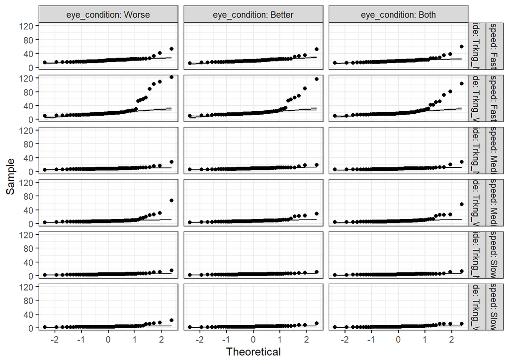

```
## ANOVA Table (type III tests)
##
##                      Effect  DFn   DFd       F        p p<.05   pes
## 1             eye_condition 1.65 92.43   0.989 3.62e-01       0.017
## 2                     speed 1.04 58.23 174.867 1.62e-19     * 0.757
## 3                     guide 1.00 56.00   4.292 4.30e-02     * 0.071
## 4       eye_condition:speed 1.64 91.86   0.822 4.22e-01       0.014
## 5       eye_condition:guide 1.41 78.98   0.631 4.81e-01       0.011
## 6               speed:guide 1.07 59.91   7.586 7.00e-03     * 0.119
## 7 eye_condition:speed:guide 1.68 93.94   0.408 6.30e-01       0.007
```

## Tracking - Interoccular difference > 0.2 logMAR removed

Some conditions are not normally distributed, see qq plot for details

No main effect of eye condition. Main effect of guide and speed, and a sig. guide*speed interaction.

```
## # A tibble: 18 x 7
##    guide    speed eye_condition variable     n  mean    sd
##    <fct>    <fct> <fct>         <chr>    <dbl> <dbl> <dbl>
##  1 Trkng_NG Fast  Worse         RMSE        60 20.3   6.35
##  2 Trkng_NG Fast  Better        RMSE        60 19.8   6.19
##  3 Trkng_NG Fast  Both          RMSE        60 19.4   7
##  4 Trkng_NG Medi  Worse         RMSE        60  9.02  3.24
##  5 Trkng_NG Medi  Better        RMSE        60  8.85  2.13
##  6 Trkng_NG Medi  Both          RMSE        60  8.65  3.32
##  7 Trkng_NG Slow  Worse         RMSE        60  4.96  2.13
##  8 Trkng_NG Slow  Better        RMSE        60  4.85  1.54
##  9 Trkng_NG Slow  Both          RMSE        60  4.55  1.78
## 10 Trkng_WG Fast  Worse         RMSE        60 27.2  24.6
## 11 Trkng_WG Fast  Better        RMSE        60 24.6  19.3
## 12 Trkng_WG Fast  Both          RMSE        60 22.6  13.5
## 13 Trkng_WG Medi  Worse         RMSE        60 10.1   9.10
## 14 Trkng_WG Medi  Better        RMSE        60  8.96  4.61
## 15 Trkng_WG Medi  Both          RMSE        60  9.66  7.82
## 16 Trkng_WG Slow  Worse         RMSE        60  4.81  3.36
## 17 Trkng_WG Slow  Better        RMSE        60  4.40  1.75
## 18 Trkng_WG Slow  Both          RMSE        60  4.54  2.37
```

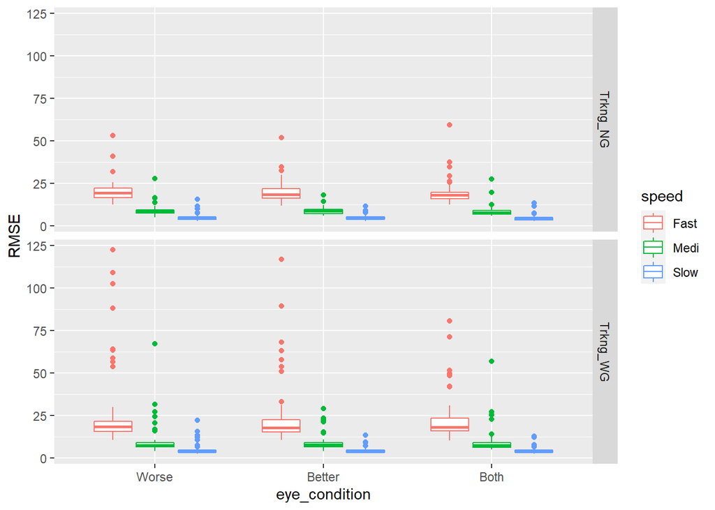

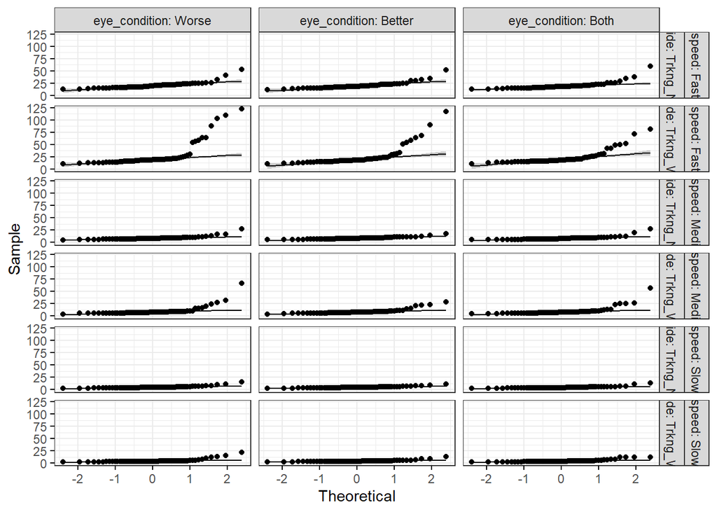

```
## ANOVA Table (type III tests)
##
##                      Effect  DFn    DFd       F        p p<.05   pes
## 1             eye_condition 1.73 102.22   2.105 1.34e-01       0.034
## 2                     speed 1.03  61.05 188.565 1.23e-20     * 0.762
## 3                     guide 1.00  59.00   6.024 1.70e-02     * 0.093
## 4       eye_condition:speed 1.89 111.56   2.056 1.35e-01       0.034
## 5       eye_condition:guide 1.40  82.64   1.375 2.54e-01       0.023
## 6               speed:guide 1.06  62.70   9.750 2.00e-03     * 0.142
## 7 eye_condition:speed:guide 1.91 112.65   2.081 1.32e-01       0.034
```

```
## # A tibble: 3 x 10
##   .y.   group1 group2    n1    n2 statistic    df     p p.adj p.adj.signif
## * <chr> <chr>  <chr>  <int> <int>     <dbl> <dbl> <dbl> <dbl> <chr>
## 1 RMSE  Worse  Better   360   360     2.38    359 0.018 0.053 ns
## 2 RMSE  Worse  Both     360   360     2.37    359 0.018 0.053 ns
## 3 RMSE  Better Both     360   360     0.895   359 0.371 0.371 ns
```

```
## # A tibble: 3 x 7
##   .y.   group1 group2 effsize    n1    n2 magnitude
## * <chr> <chr>  <chr>    <dbl> <int> <int> <ord>
## 1 RMSE  Worse  Better  0.126    360   360 negligible
## 2 RMSE  Worse  Both    0.125    360   360 negligible
## 3 RMSE  Better Both    0.0472   360   360 negligible
```

## Tracking - Interoccular difference < 0.2 logMAR removed

WG-Fast-Both - has a really high mean RMSE (~24) - Participant 116 has error of 103.74 for this condition

main effect of speed only

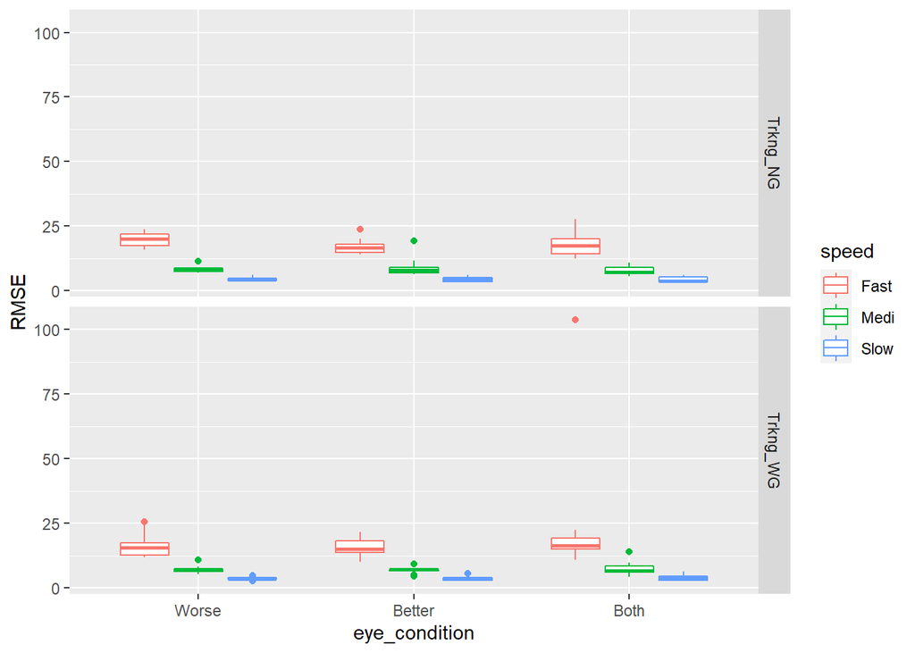

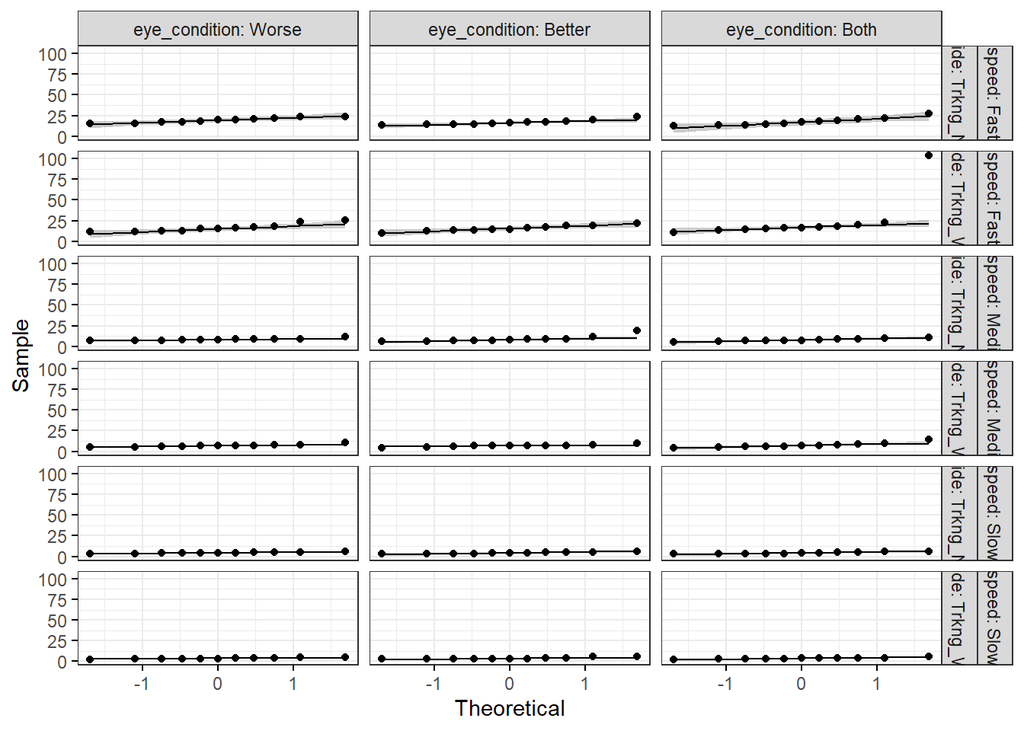

```
## ANOVA Table (type III tests)
##
##                      Effect  DFn   DFd      F        p p<.05   pes
## 1             eye_condition 1.05 10.46  0.506 5.00e-01       0.048
## 2                     speed 1.06 10.61 82.934 2.03e-06     * 0.892
## 3                     guide 1.00 10.00  0.164 6.94e-01       0.016
## 4       eye_condition:speed 1.03 10.30  0.953 3.54e-01       0.087
## 5       eye_condition:guide 1.08 10.77  2.035 1.82e-01       0.169
## 6               speed:guide 1.02 10.20  0.557 4.76e-01       0.053
## 7 eye_condition:speed:guide 1.05 10.53  1.517 2.47e-01       0.132
```